# Pine Environment Summary

Katie Lotterhos

April 24, 2015

Data used here is stored on Lotterhos’ laptop * /Users/katie/Desktop/AdaptreeData/2015_POST_FILTERING/pine_src/envi_clusters

### Hierarchical clustering of the environmental variables used in this study

We performed a hierarchical cluster analysis on the 22 environmental variables as a way to summarize the outliers and account for correlated variables.

```r
env.clust <- read.table("../pine_data/sprucePineEnvi.clusters", header=TRUE)
env.clust
```

```
##      enviAbb                   enviDesc G3 G4
## 1        LAT                   Latitude  1  0
## 2       LONG                  Longitude  2  0
## 3  ELEVATION                  Elevation  3  0
## 4        MAT             Mean ann. temp  1  1
## 5       MWMT         Mean warmest month  3  3
## 6       MCMT         Mean coldest month  1  1
## 7         TD            Temp difference  1  1
## 8        MAP  Mean annual precipitation  2  2
## 9        MSP  Mean summer precipitation  2  2
## 10       AHM Anuual heat:moisture index  2  2
## 11       SHM Summer heat:moisture index  2  2
## 12      DD_0                  Days < 0C  1  1
## 13       DD5                  Days > 5C  3  3
## 14      NFFD          # frost-free days  3  3
## 15      bFFP    Begin frost-free period  3  3
## 16      eFFP      End frost-free period  3  3
## 17       FFP          Frost-free period  3  3
## 18       PAS      Precipitation as snow  2  2
## 19       EMT Extreme min. temp 30 years  1  1
## 20       EXT Extreme max. temp 30 years  2  2
## 21      Eref                Evaporation  2  2
## 22       CMD   Climate moisture deficit  2  2
```

In the table above, column G3 represents the group from the hierarchical clustering. For analysis, we took out Latitude, Longitude, and Elevation and analyzed them separately because they do not represent environments per se but rather variables that correlate with other selective pressures that we didn’t measure (for example elevation may correlate with UV exposure). So column G4 was used for analysis.

An image of the clustered environments for pine:

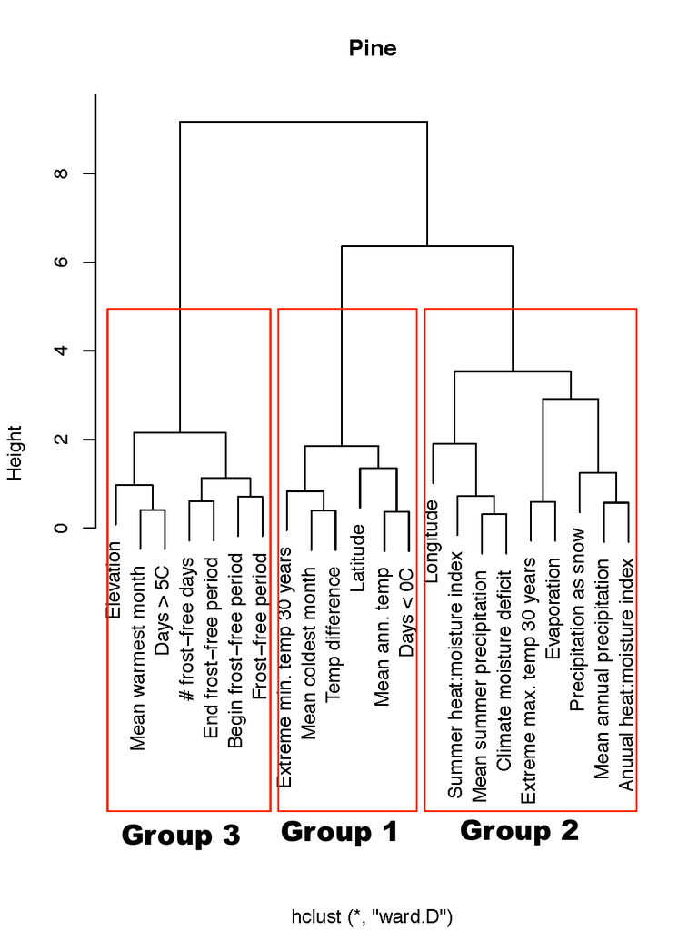

The environments cluster into three groups. Group 1 contains variables that correlate with mean annual temperature, Group 2 contains variables that correlate with mean annual precipitation, and Group 3 contains variables that correlate with frost-free period.

As one mechanism to measure adaptation to correlated environmental variables, outlier SNPs were grouped into these three categories.

### Principal components of the environmental variables used in this study

As a second mechanism to measure adaptation to correlated environmental variables, we performed a principal components analysis.

```r
env <- read.table("../pine_data/var_out_pine_all_COMBINED.table.contig_flt10.bayenv.envi2")
#head(env)

in2 <- t (env)
in3 <- prcomp (in2, scale. = T)
str(in3)
```

```
## List of 5
##  $ sdev    : num [1:22] 3.11 2.21 1.83 1.39 1.02 ...
##  $ rotation: num [1:22, 1:22] -0.1294 -0.0628 -0.1873 0.3031 0.2437 ...
##   ..- attr(*, "dimnames")=List of 2
##   .. ..$ : NULL
##   .. ..$ : chr [1:22] "PC1" "PC2" "PC3" "PC4" ...
##  $ center  : num [1:22] 0.05162 -0.00267 -0.00101 -0.04268 -0.03664 ...
##  $ scale   : num [1:22] 0.9 0.99 0.97 0.92 0.939 ...
##  $ x       : num [1:279, 1:22] 0.112 -0.741 -2.341 -0.396 -0.963 ...
##   ..- attr(*, "dimnames")=List of 2
##   .. ..$ : chr [1:279] "V1" "V2" "V3" "V4" ...
##   .. ..$ : chr [1:22] "PC1" "PC2" "PC3" "PC4" ...
##  - attr(*, "class")= chr "prcomp"
```

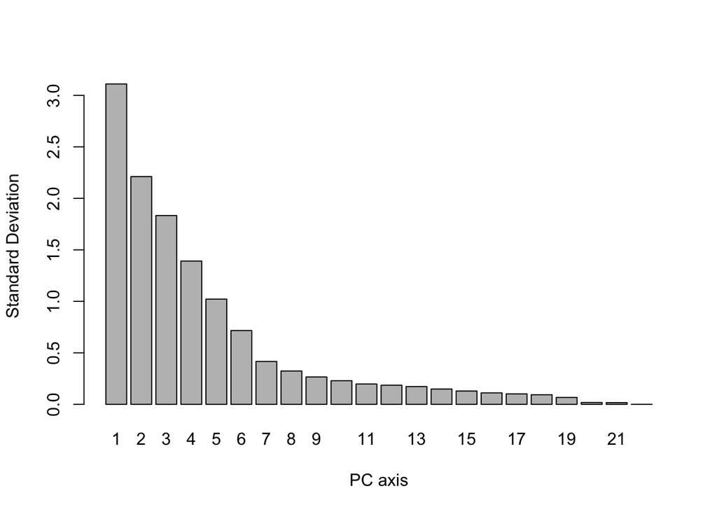

```r
scores <- t (in3$x)
#head(scores)
#write.table (scores,"var_out_pine_all_COMBINED.table.contig_flt10.bayenv.envi2_PCA", col.names = F, row.names = F, quote = F)
#write.table (scores,"seqcap.bayenv.BF.envi2_PCA", col.names = F, row.names = F, quote = F)
barplot(in3$sdev, ylab="Standard Deviation", names.arg = 1:22, xlab="PC axis")
```

#### Distribution of environments along PC axes

```r
loadings <- in3$rotation
dim(loadings)
```

```
## [1] 22 22
```

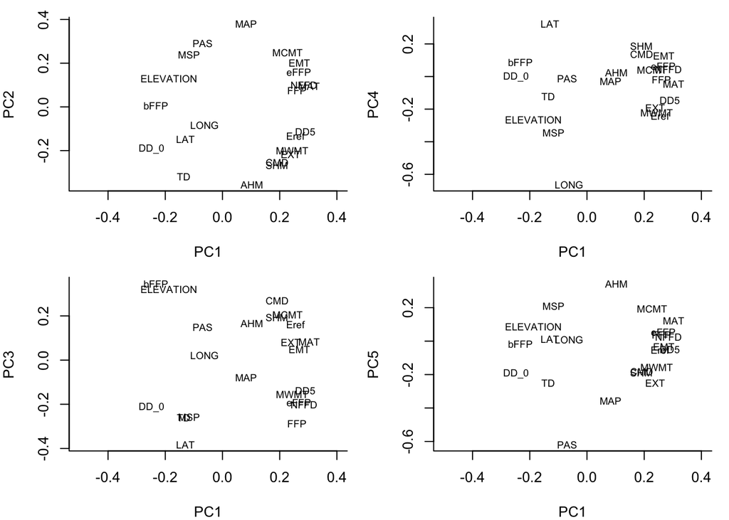

```r
par(mfcol=c(2,2), mar=c(4,4,1,1))
  ### Left column
  plot(loadings[,1], loadings[,2], xlab="PC1", ylab="PC2", col=0, bty="l", xlim=c(-0.5,0.4))
  text(loadings[,1], loadings[,2], env.clust$enviAbb, cex=0.7)
  plot(loadings[,1], loadings[,3], xlab="PC1", ylab="PC3", col=0, bty="l", xlim=c(-0.5,0.4))
  text(loadings[,1], loadings[,3], env.clust$enviAbb, cex=0.7)

  ### Right column
  plot(loadings[,1], loadings[,4], xlab="PC1", ylab="PC4", col=0, bty="l", xlim=c(-0.5,0.4))
  text(loadings[,1], loadings[,4], env.clust$enviAbb, cex=0.7)
  plot(loadings[,1], loadings[,5], xlab="PC1", ylab="PC5", col=0, bty="l", xlim=c(-0.5,0.4))
  text(loadings[,1], loadings[,5], env.clust$enviAbb, cex=0.7)
```

#### Table and graphs of loadings for first 5 PC axes

```r
  rownames(loadings) <- env.clust$enviAbb
 loadings[,1:5]
```

```
##                   PC1          PC2         PC3          PC4         PC5
## LAT       -0.12941796 -0.147830843 -0.38215730  0.324298380  0.01390328
## LONG      -0.06281389 -0.083390092  0.02175263 -0.662587791  0.01062978
## ELEVATION -0.18730157  0.130419302  0.32075674 -0.263292905  0.08673137
## MAT        0.30309538  0.095389248  0.08278281 -0.045388281  0.12231908
## MWMT       0.24370040 -0.199243050 -0.15356411 -0.220877936 -0.15714206
## MCMT       0.22776821  0.247927146  0.20655770  0.039822267  0.19558006
## TD        -0.13560947 -0.317912931 -0.26030734 -0.120309573 -0.25077701
## MAP        0.08243127  0.380711208 -0.07837424 -0.026842111 -0.35638648
## MSP       -0.11733279  0.239760500 -0.25779057 -0.342923219  0.21128904
## AHM        0.10303157 -0.355145003  0.16561945  0.024196438  0.34337305
## SHM        0.18994471 -0.266112574  0.19292646  0.188753428 -0.18890835
## DD_0      -0.24765824 -0.191155433 -0.21294495 -0.001022964 -0.19310807
## DD5        0.28993207 -0.113175422 -0.13880046 -0.146225300 -0.04912151
## NFFD       0.28494543  0.100463068 -0.20004310  0.045497887  0.02670573
## bFFP      -0.23286488  0.006104828  0.34593595  0.088620046 -0.01837078
## eFFP       0.26705805  0.158823655 -0.19111783  0.063953296  0.05280741
## FFP        0.26042737  0.075428895 -0.28585144 -0.018610851  0.03729614
## PAS       -0.06926353  0.290498767  0.14994053 -0.012455791 -0.61825722
## EMT        0.26869623  0.200934793  0.04939766  0.126641029 -0.03158063
## EXT        0.23832585 -0.215655961  0.08176197 -0.191405642 -0.24904991
## Eref       0.25513572 -0.132241281  0.16163591 -0.239789827 -0.05239787
## CMD        0.19130090 -0.253626342  0.26873276  0.137753707 -0.18216654
```

Note that the y-axis in the following graphs are meaningless, environments are just stacked for easy readability.

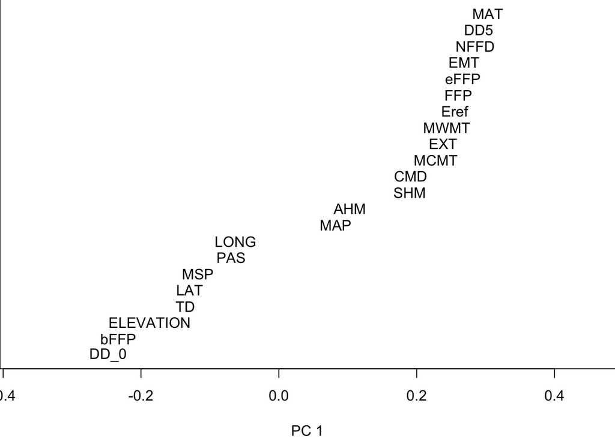

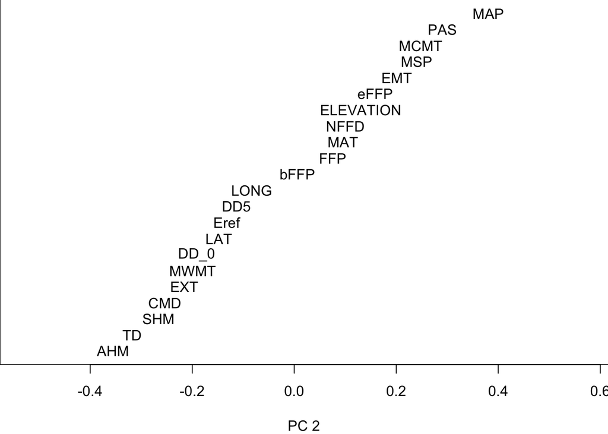

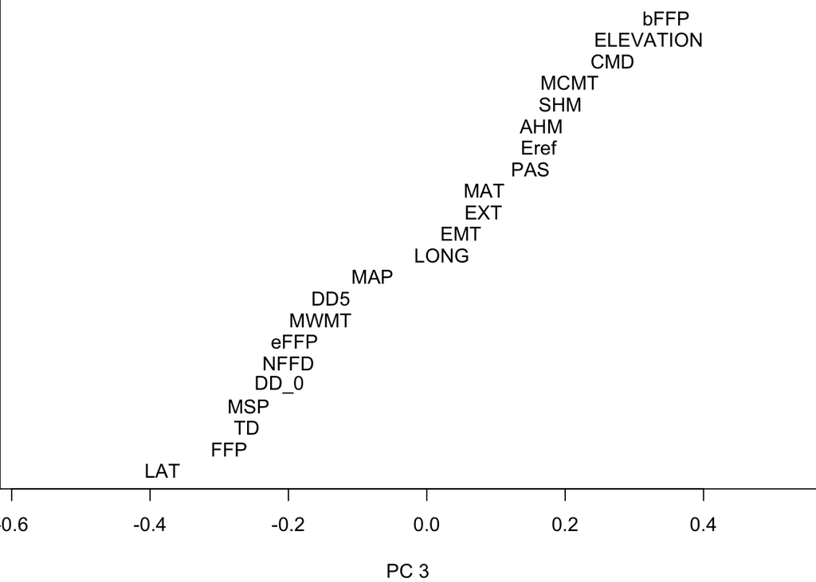

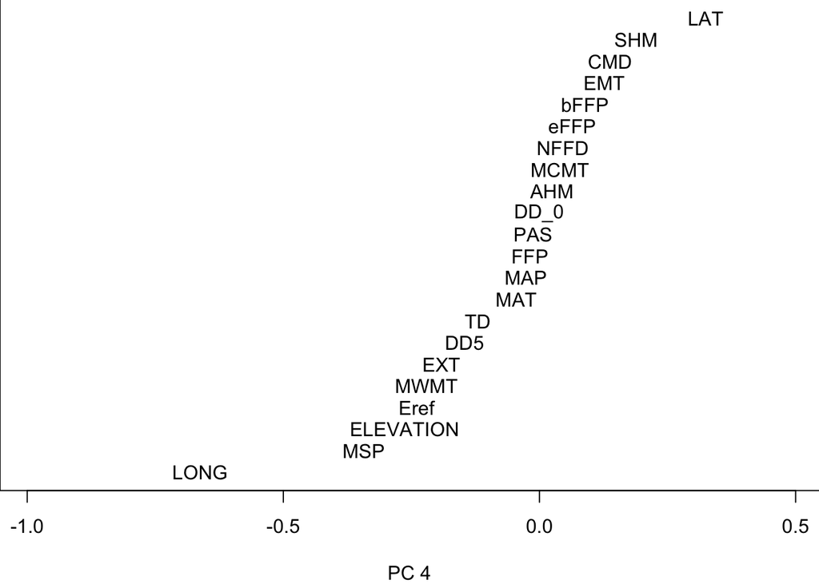

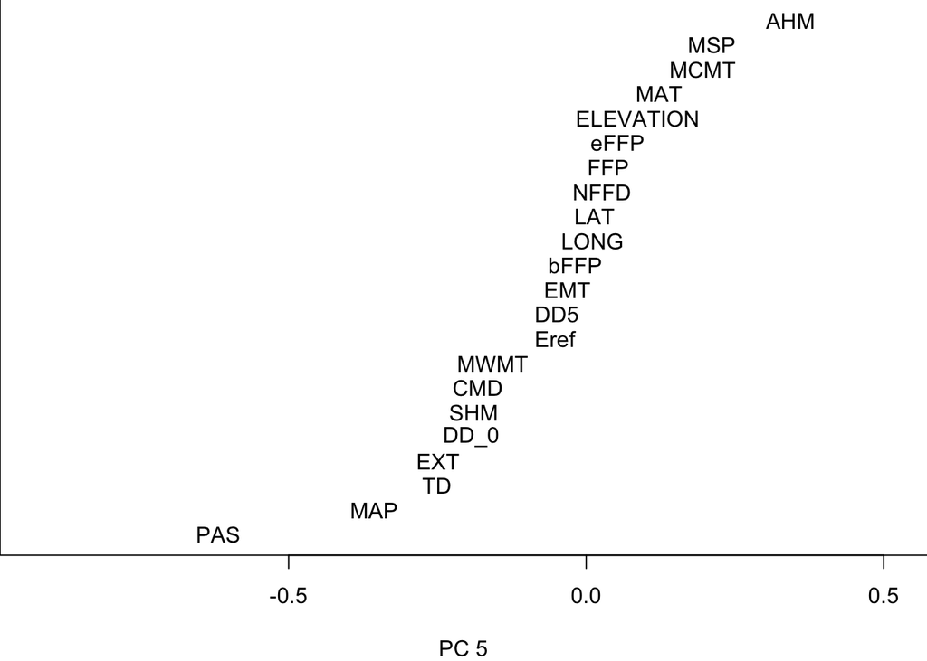

```r
  par(mfrow=c(1,1), mar=c(4,0,0,0))
  makePCplot <- function(pc){
    plot(loadings[,pc], (rank(loadings[,pc])), bty="l", yaxt="n", ylab="", xlab=paste("PC", pc), col=0, xlim=c(min(loadings[,pc])*1.5, max(loadings[,pc])*1.5))
    text(loadings[,pc], (rank(loadings[,pc])), env.clust$enviAbb)
  }
  for (i in 1:5){
  makePCplot(i)
  }
```

#### Distribution of populations along PC axes

Note that this is the distribution of populations along PC axes with respect to their *environments*, not with respect to their *genetic structure*. Some of these populations might be considered outliers with respect to the environments they experience.

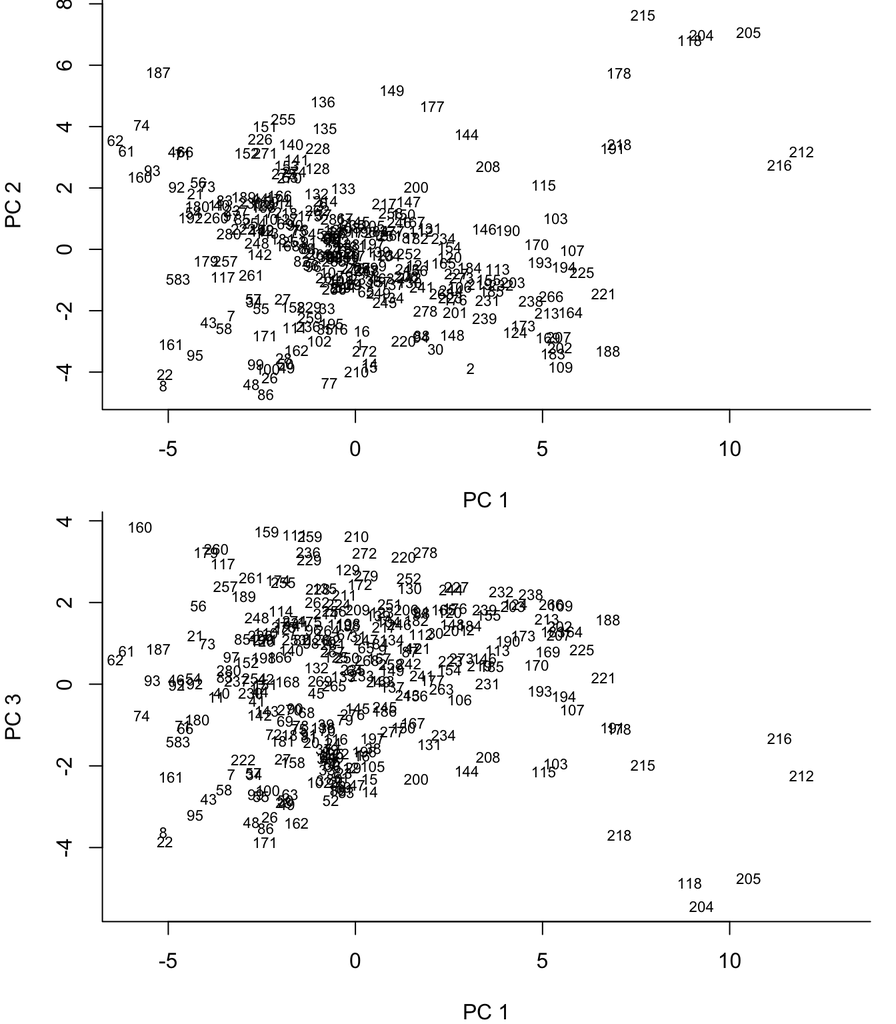

```r
popnames <- sub("Pi_", "", as.character(unlist(read.table("../pine_data/var_out_pine_all_COMBINED.table.contig_flt10.bayenv.envi.finalpops2"))))
par(mfcol=c(2,1), mar=c(4,4,0,1))
plot(scores[1,], scores[2,], xlab="PC 1", ylab="PC 2", col=0,  bty="l", xlim=c(-6,13))
  text(scores[1,], scores[2,], popnames, cex=0.7)
plot(scores[1,], scores[3,], xlab="PC 1", ylab="PC 3", col=0,  bty="l", xlim=c(-6,13))
  text(scores[1,], scores[3,], popnames, cex=0.7)
```

### Histograms of the standardized environmental variables used in this study

Environments were scaled to have a mean of 0 and a standard deviation of 1 for Bayenv analysis

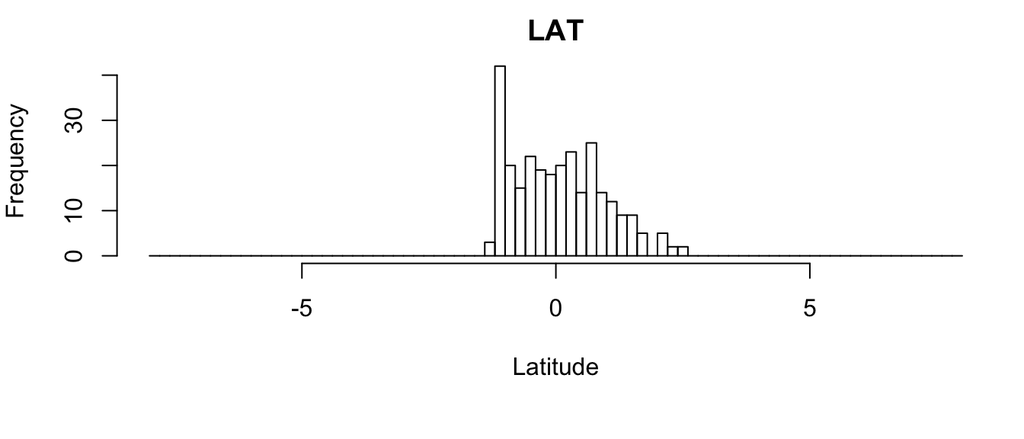

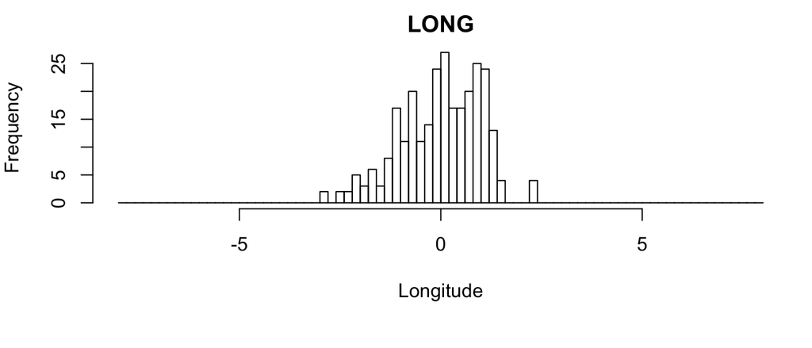

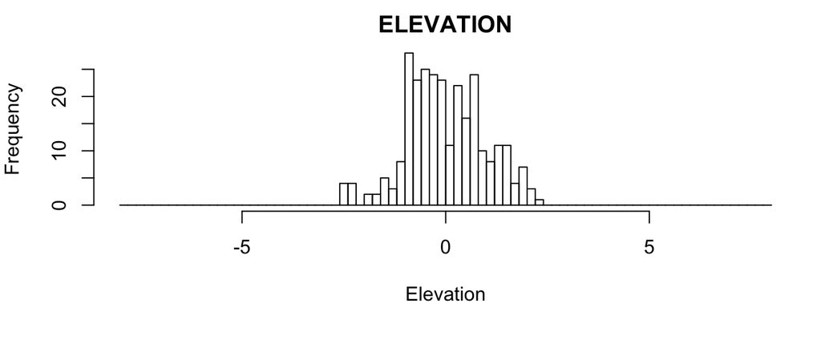

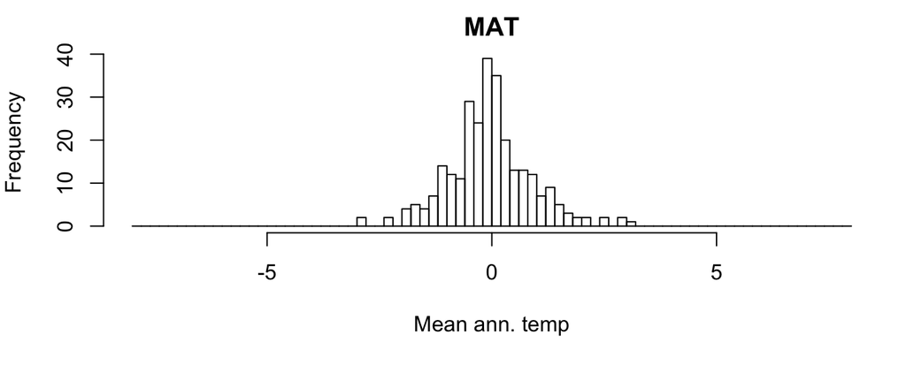

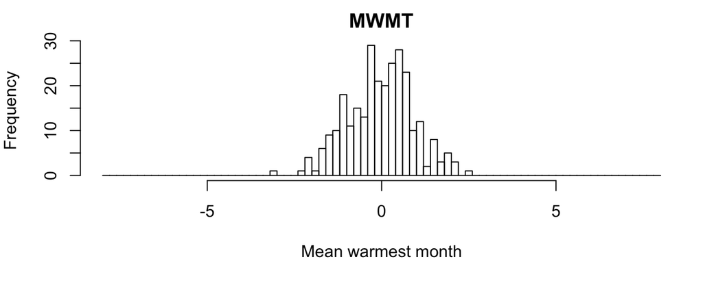

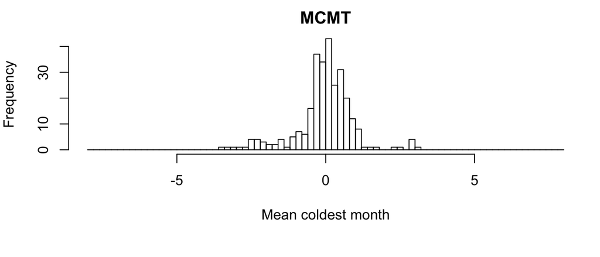

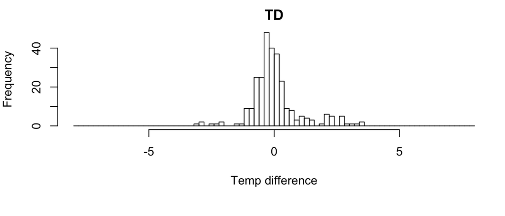

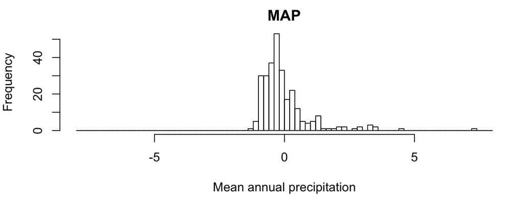

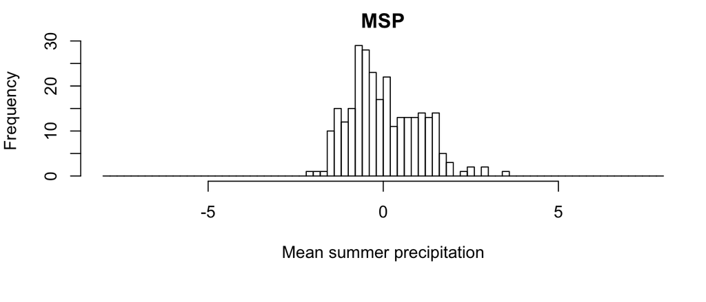

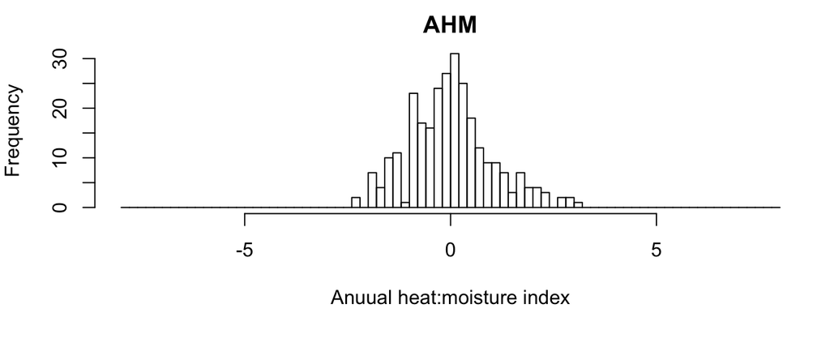

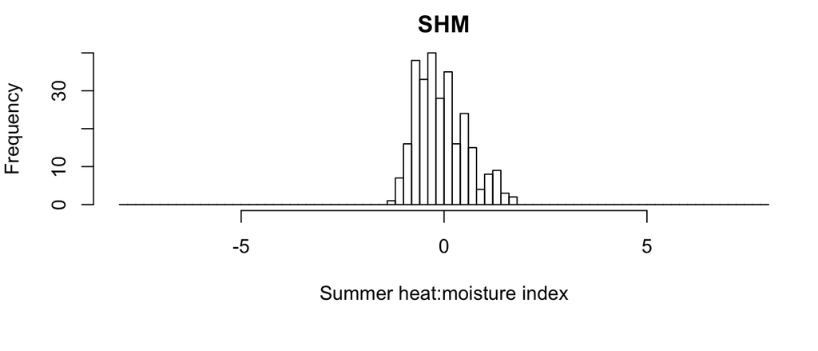

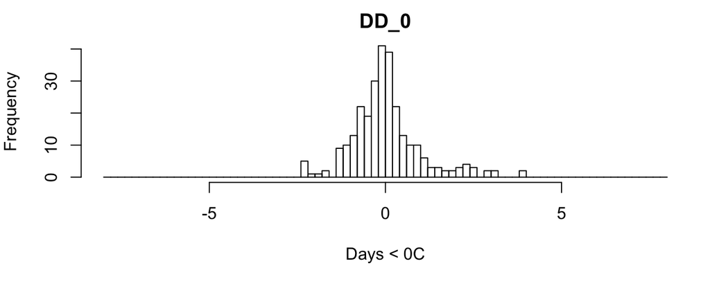

[10 more figures not shown]

```r
#head(env)
env2<-matrix(unlist(env), ncol=ncol(env))
par(mfrow=c(1,1), mar=c(6,4,2,1))
  for (i in 1:22){
    hist(env2[i,], main=env.clust$enviAbb[i], xlab=env.clust$enviDesc[i],
         xlim=c(-8,8), breaks=seq(-8,8,0.2))
  }
```